# Glioblastoma_scRNAseq_TME

- Show All Code
- Hide All Code
- View Source

Authors

Azzeddine ALILICHE

Anais HLUSZKO

Corentin OSTA

Published

November 17, 2026

```r
the.seed <- 42
set.seed(the.seed)
suppressPackageStartupMessages({
  library(Seurat)
  library(dplyr)
  library(ggplot2)
  library(gprofiler2)
})
```

```r
sample.name <- "brain_DV200"
```

**The tumour microenvironment (TME)**

In glioblastoma, the main non-tumour cells are the **tumour-associated macrophages (TAMs)**. They come from two origins : **microglia** (the resident macrophages of the brain) and **bone marrow-derived macrophages (BDM)** recruited from the blood. BDM are often linked to a more immunosuppressive environment. We also look at the few T cells : glioblastoma is a “cold” tumour with few, often exhausted, T cells.

```r
load(paste0('../data/processed_data/', sample.name, '_STATES.rda'))

# myeloid cells not called malignant by inferCNV
myeloid <- subset(sobjFiltrd, subset = celltype == "Myeloid" & cnv_status == "Normal")
ncol(myeloid)
```

```
[1] 547
```

## Origin of the TAMs : microglia or BDM ?

Microglia express P2RY12, TMEM119, CX3CR1 or SALL1, BDM and monocytes express CD163, MRC1, TGFBI, CCR2 or ITGA4 (CD49d).

```r
mg_genes <- c("P2RY12", "TMEM119", "CX3CR1", "SALL1", "P2RY13")
bdm_genes <- c("CD163", "MRC1", "TGFBI", "CCR2", "ITGA4", "LYZ", "FCN1")

c(mg_genes, bdm_genes)[!c(mg_genes, bdm_genes) %in% rownames(myeloid)]  # genes missing from the probe panel
```

```
[1] "FCN1"
```

```r
myeloid <- AddModuleScore(myeloid, features = list(intersect(mg_genes, rownames(myeloid)),
                                                   intersect(bdm_genes, rownames(myeloid))),
                          name = "origin_", seed = the.seed)
myeloid$score_microglia <- myeloid$origin_1
myeloid$score_BDM <- myeloid$origin_2
myeloid$origin <- ifelse(myeloid$score_microglia > myeloid$score_BDM, "Microglia-like", "BDM-like")

table(myeloid$origin)
```

```
      BDM-like Microglia-like
           337            210
```

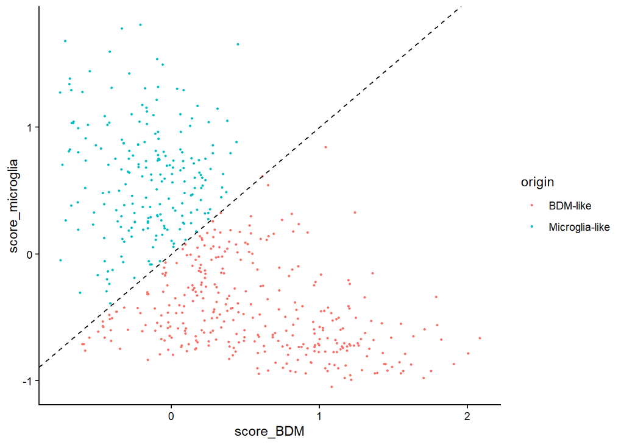

```r
ggplot(myeloid@meta.data, aes(x = score_BDM, y = score_microglia, colour = origin)) +
  geom_point(size = 0.6) + geom_abline(linetype = "dashed") + theme_classic()
```

**Observation** : about 2/3 of the TAMs look BDM-like and 1/3 microglia-like. A large share of recruited macrophages is typical of glioblastoma. The two scores form a continuum rather than two separate groups, so the split is approximate (FCN1 is not in the probe panel).